# Analytic Objective 1: Code Script

Author

Kiki Shimomae (Group 1)

Published

April 17, 2025

# 1 Brief Description about Project

- The project is about Customer Satisfaction in the Airline Industry: Client Consulting Project for United Airlines.
- The research uses a secondary dataset that was collected and provided by an anonymized real airline company for proprietary reasons.
- The lead faculty is Dr. Shih-Tang Hwu.

# 2 Data Wrangling

- Created data called AO1data which only contains variables needed for Analytic Objective 1.
- Rename variables by replacing first letter to uppercase for consistency.
- Original dataset was mostly cleaned and formatted, thus, minor cleaning such as renaming variables was needed.

```r
library(dplyr)
library(gt)
library(gtExtras)
library(ggplot2)
library(reshape2)
library(tidyr)
library(readxl)

data = readxl::read_excel("Updated_cleaned.xlsx")

AO1data = select(data, Satisfied = y, Wifi = wifi, Food, Entertainment = entertainment, Cleanliness, Service = service, Onboard_service = On_board_service)
```

# 3 Analytics Objectives 1: Influence of Inflight Service Quality on Satisfaction - Kiki Shimomae

- This objective explores how various in-flight services — such as WiFi service, food and drinks, entertainment, cleanliness, and on-board services — affect overall customer satisfaction.

# 4 Descriptive Analytics for AO1

**Note**

For Analytic Objective 1, I used **Frequency**, **Percentage**, **Mode** and **Range** as descriptive analytics.

## 4.1 Frequency and Percentage

> - 1. Frequency and Percentage for Satisfaction variable. This is binary variable and 1 = Satisfied, 0 = Neutral or Dissatisfied.

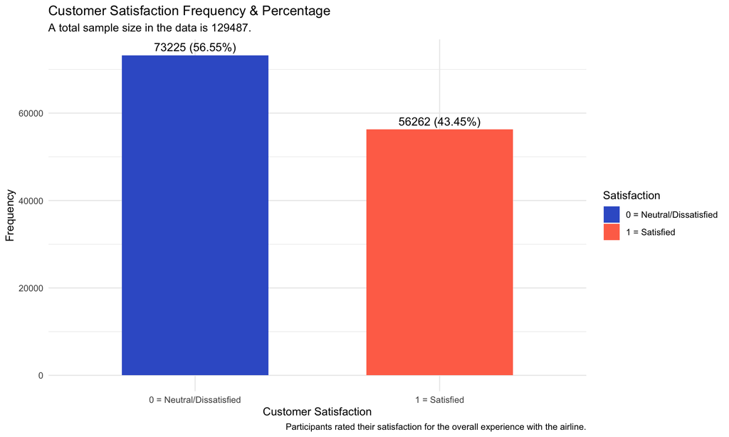

Figure 1: Descriptive Statistics (Frequency & Percentage) of a binary variable called Customer Satisfaction

```r
Satisfaction_freq <- AO1data %>%
  group_by(Satisfied) %>%
  summarise(Frequency = n()) %>%
  mutate(Percentage = round(Frequency / sum(Frequency) * 100, 2),
         Satisfaction_Label = ifelse(Satisfied == 1, "1 = Satisfied", "0 = Neutral/Dissatisfied"))

ggplot(Satisfaction_freq, aes(x = Satisfaction_Label, y = Frequency, fill = Satisfaction_Label)) +
  geom_bar(stat = "identity", width = 0.6) +
  geom_text(aes(label = paste0(Frequency, " (", Percentage, "%)")),
            vjust = -0.5, size = 4) +
  scale_fill_manual(values = c("0 = Neutral/Dissatisfied" = "royalblue3",
                               "1 = Satisfied" = "coral1")) +
  labs(x = "Customer Satisfaction",
       y = "Frequency",
       fill = "Satisfaction",
       title = "Customer Satisfaction Frequency & Percentage",
       subtitle = "A total sample size in the data is 129487.",
       caption = "Participants rated their satisfaction for the overall experience with the airline.") +
  theme_minimal() +
  theme(legend.position = "right")
```

> - 2. Frequency and Percentage for Inflight Service Attribute which were measured by 6 point Likert Scale. The result was visualized as stacked bar chart for easier comparison across different variables.

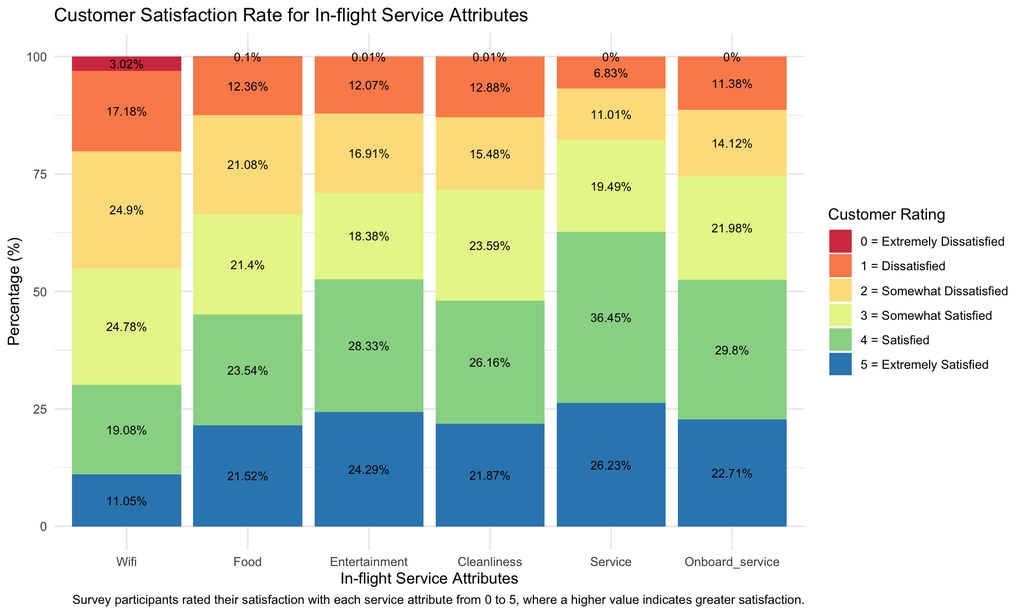

Figure 2: Descriptive Statistics (Frequency & Percentage) of Inflight Service Variables measured by 6 point Likert Scale

```r
data_long <- melt(AO1data[, -1], variable.name = "Attribute", value.name = "Rating")

likert_summary <- data_long %>%
  group_by(Attribute, Rating) %>%
  summarise(Frequency = n()) %>%
  mutate(Percentage = round(Frequency / sum(Frequency) * 100, 2))

rating_labels <- c("0 = Extremely Dissatisfied",
                   "1 = Dissatisfied",
                   "2 = Somewhat Dissatisfied",
                   "3 = Somewhat Satisfied",
                   "4 = Satisfied",
                   "5 = Extremely Satisfied")

ggplot(likert_summary, aes(x = Attribute, y = Percentage, fill = factor(Rating, levels=0:5, labels=rating_labels))) +
  geom_bar(stat = "identity") +
  geom_text(aes(label = paste0(Percentage, "%")), position = position_stack(vjust = 0.5), size=3) +
  labs(x = "In-flight Service Attributes",
       y = "Percentage (%)",
       fill = "Customer Rating",
       title = "Customer Satisfaction Rate for In-flight Service Attributes",
       caption = "Survey participants rated their satisfaction with each service attribute from 0 to 5, where a higher value indicates greater satisfaction.") +
  theme_minimal() +
  scale_fill_brewer(palette = "Spectral") +
  theme(legend.position = "right")
```

## 4.2 Mode and Range

> - Mode and Range for all the variables for AO1. The result is visualized in a table below.

```r
df <- AO1data

# Variables to analyze
variables <- c('Wifi', 'Food', 'Entertainment', 'Cleanliness', 'Service', 'Onboard_service')

# Mode function
get_mode <- function(x) {
  uniqx <- unique(x)
  uniqx[which.max(tabulate(match(x, uniqx)))]
}

# Calculate mode and range
stats_df <- data.frame(
  Variable = variables,
  Mode = sapply(df[variables], get_mode),
  Min = sapply(df[variables], min),
  Max = sapply(df[variables], max)
)
stats_df <- stats_df %>% mutate(Range = Max - Min)

# Create a detailed, reproducible table using gt
stats_df %>%
  gt() %>%
  tab_header(
    title = "Mode and Range of Customer Satisfaction on Inflight Service",
    subtitle = "Participants rated their satisfaction with each service attribute from 0 to 5, where a higher value indicates greater satisfaction."
  ) %>%
  cols_label(
    Variable = "Inflight Service Variable",
    Mode = "Mode",
    Min = "Minimum Rating",
    Max = "Maximum Rating",
     Range = "Range of Ratings"
  ) %>%
  tab_footnote(
    footnote = "Mode indicates the most commonly selected rating from the data.",
    locations = cells_column_labels(columns = Mode)
  ) %>%
  tab_source_note(
    source_note = "Source: Customer Satisfaction Survey conducted in 2015 by anonymized real airline company"
  ) %>%
  fmt_number(columns = c(Mode, Min, Max, Range), decimals = 0) |>
opt_table_font(font = google_font("Lato")) %>%
  opt_row_striping() %>%
  tab_options(table.border.top.color = "navyblue", table.border.bottom.color = "navyblue")
```

Mode and Range of Customer Satisfaction on Inflight Service

Participants rated their satisfaction with each service attribute from 0 to 5, where a higher value indicates greater satisfaction.

| Inflight Service Variable | Mode<sup>1</sup> | Minimum Rating | Maximum Rating | Range of Ratings |
| --- | --- | --- | --- | --- |
| Wifi | 2 | 0 | 5 | 5 |
| Food | 4 | 0 | 5 | 5 |
| Entertainment | 4 | 0 | 5 | 5 |
| Cleanliness | 4 | 0 | 5 | 5 |
| Service | 4 | 0 | 5 | 5 |
| Onboard_service | 4 | 0 | 5 | 5 |

Source: Customer Satisfaction Survey conducted in 2015 by anonymized real airline company  
<sup>1</sup> Mode indicates the most commonly selected rating from the data.

# 5 Predictive Analytics and Results

> - Logistic regression and decision tree.

# 6 Logistic Regression

```r
cleaned <- read_excel("Updated_cleaned.xlsx")

# 1. Fit the Logistic Regression Model with All Effects

mod <- glm(y ~ . + I(Age * Seat) + I(Customer * Biztravel) + I(Distance * Baggage) + I(online_board * wifi) + I(Female * Leg_room) + I(Food * Distance) + I(Food * Seat) + I(Biztravel * wifi) + I(entertainment * Eco) + I(online_book * Biztravel) + I(online_board * Customer) + I(On_board_service * Leg_room) + I(Total_delay * Biztravel) + I(Total_delay * Age) + I(wifi * Age), family = "binomial", data = cleaned)

# View summary of the model
summary(mod)
```

```
Call:
glm(formula = y ~ . + I(Age * Seat) + I(Customer * Biztravel) +
    I(Distance * Baggage) + I(online_board * wifi) + I(Female *
    Leg_room) + I(Food * Distance) + I(Food * Seat) + I(Biztravel *
    wifi) + I(entertainment * Eco) + I(online_book * Biztravel) +
    I(online_board * Customer) + I(On_board_service * Leg_room) +
    I(Total_delay * Biztravel) + I(Total_delay * Age) + I(wifi *
    Age), family = "binomial", data = cleaned)

Coefficients:
                                 Estimate Std. Error z value Pr(>|z|)
(Intercept)                    -4.219e+00  3.140e-01 -13.434  < 2e-16 ***
Female                         -5.286e-01  5.198e-02 -10.170  < 2e-16 ***
Customer                        2.020e-01  2.703e-01   0.747  0.45492
Age                            -1.423e-02  2.417e-03  -5.889 3.89e-09 ***
Biztravel                       1.163e+00  2.728e-01   4.262 2.02e-05 ***
Eco                             1.764e-01  5.581e-02   3.161  0.00157 **
Ecoplus                        -1.012e+00  4.001e-02 -25.291  < 2e-16 ***
Distance                       -8.577e-04  4.036e-05 -21.249  < 2e-16 ***
wifi                            1.884e-01  4.064e-02   4.637 3.53e-06 ***
time_convenient                -1.140e-01  8.018e-03 -14.215  < 2e-16 ***
online_book                    -9.909e-01  3.048e-02 -32.511  < 2e-16 ***
gate                            4.874e-02  9.036e-03   5.394 6.91e-08 ***
Food                           -3.462e-01  2.454e-02 -14.111  < 2e-16 ***
online_board                   -1.941e-01  2.187e-02  -8.878  < 2e-16 ***
Seat                           -2.188e-01  2.923e-02  -7.484 7.19e-14 ***
entertainment                   3.272e-01  1.572e-02  20.814  < 2e-16 ***
On_board_service               -9.839e-02  2.070e-02  -4.753 2.01e-06 ***
Leg_room                       -2.387e-01  2.120e-02 -11.259  < 2e-16 ***
Baggage                        -4.421e-03  1.398e-02  -0.316  0.75175
Checkin                         3.385e-01  8.113e-03  41.726  < 2e-16 ***
service                         1.007e-01  1.142e-02   8.814  < 2e-16 ***
Cleanliness                     2.672e-01  1.169e-02  22.856  < 2e-16 ***
Total_delay                    -8.026e-03  6.309e-04 -12.721  < 2e-16 ***
I(Age * Seat)                   5.322e-03  5.302e-04  10.038  < 2e-16 ***
I(Customer * Biztravel)         3.029e+00  2.634e-01  11.499  < 2e-16 ***
I(Distance * Baggage)           1.255e-04  8.609e-06  14.583  < 2e-16 ***
I(online_board * wifi)          4.245e-01  5.524e-03  76.842  < 2e-16 ***
I(Female * Leg_room)            1.686e-01  1.494e-02  11.289  < 2e-16 ***
I(Food * Distance)              1.407e-04  7.880e-06  17.857  < 2e-16 ***
I(Food * Seat)                  3.433e-02  5.631e-03   6.097 1.08e-09 ***
I(Biztravel * wifi)            -1.246e+00  3.584e-02 -34.761  < 2e-16 ***
I(entertainment * Eco)         -3.046e-01  1.589e-02 -19.165  < 2e-16 ***
I(online_book * Biztravel)      8.126e-01  3.250e-02  24.999  < 2e-16 ***
I(online_board * Customer)     -2.815e-01  2.152e-02 -13.081  < 2e-16 ***
I(On_board_service * Leg_room)  1.229e-01  5.754e-03  21.361  < 2e-16 ***
I(Total_delay * Biztravel)      5.238e-03  5.252e-04   9.974  < 2e-16 ***
I(Total_delay * Age)            2.085e-05  9.738e-06   2.141  0.03227 *
I(wifi * Age)                  -2.338e-03  5.360e-04  -4.361 1.30e-05 ***
---
Signif. codes:  0 '***' 0.001 '**' 0.01 '*' 0.05 '.' 0.1 ' ' 1

(Dispersion parameter for binomial family taken to be 1)

    Null deviance: 177279  on 129486  degrees of freedom
Residual deviance:  76981  on 129449  degrees of freedom
AIC: 77057

Number of Fisher Scoring iterations: 6
```

```r
# 2. Calculate the Fitted Linear Predictor and Lower g Value

# Compute the linear predictor (β̂) for each observation
cleaned$fit <- predict(mod, type = "link")

# Calculate the derivative of the logistic function for each observation:
#    g = exp(fit) / ((1 + exp(fit))^2)
cleaned$g_lower <- exp(cleaned$fit) / ((1 + exp(cleaned$fit))^2)

# 3. Compute Pseudo R-Squared

ll_full <- logLik(mod)
mod_null <- glm(y ~ 1, family = "binomial", data = cleaned)
ll_null <- logLik(mod_null)
pseudoR2 <- 1 - as.numeric(ll_full) / as.numeric(ll_null)
cat("Pseudo R-squared:", pseudoR2, "\n")
```

```
Pseudo R-squared: 0.5657643
```

```r
# 4. Classification: Compute Percentage Correctly Predicted

predicted_probs <- mod$fitted.values
predicted_class <- ifelse(predicted_probs > 0.5, 1, 0)
pct_correct <- mean(predicted_class == cleaned$y)
cat("Percentage Correctly Predicted:", pct_correct, "\n")
```

```
Percentage Correctly Predicted: 0.8845907
```

```r
# 5. Compute Marginal Effect for 'Age'

# In logistic regression, the marginal effect for Age when it is involved in interactions
# (e.g., I(Total_delay * Age) and I(wifi * Age)) is given by:
#      ME_age = p * (1 - p) * [ coefficient_Age +
#                               (coefficient_TotalDelay_Age * Total_delay) +
#                               (coefficient_wifi_Age * wifi) ]
#
# p is the predicted probability (i.e. the logistic function applied to fit).

# Extract fitted probabilities
p <- mod$fitted.values

# Extract coefficients from the model (check names(coef(mod)) if needed)
coef_est <- coef(mod)
coef_age <- coef_est["Age"]
coef_total_delay_age <- coef_est["I(Total_delay * Age)"]
coef_wifi_age <- coef_est["I(wifi * Age)"]

# Compute the marginal effect for Age for each observation
marginal_effect_age <- p * (1 - p) * (coef_age +
                                      coef_total_delay_age * cleaned$Total_delay +
                                      coef_wifi_age        * cleaned$wifi)

# Calculate and print the average marginal effect for Age
average_me_age <- mean(marginal_effect_age)
cat("Average Marginal Effect for Age:", average_me_age, "\n")
```

```
Average Marginal Effect for Age: -0.001832326
```

```r
# 6. (Optional) Additional Diagnostic: Correlation Matrix of Numerics

# Calculate diagonal of the correlation matrix of numeric variables
# (Use only numeric columns to avoid errors)
numeric_vars <- cleaned[sapply(cleaned, is.numeric)]
diag(cor(numeric_vars))
```

```
               y           Female         Customer              Age
               1                1                1                1
       Biztravel              Eco          Ecoplus         Distance
               1                1                1                1
            wifi  time_convenient      online_book             gate
               1                1                1                1
            Food     online_board             Seat    entertainment
               1                1                1                1
On_board_service         Leg_room          Baggage          Checkin
               1                1                1                1
         service      Cleanliness      Total_delay              fit
               1                1                1                1
         g_lower
               1
```

```r
# Optionally, view the first few rows of the new variables (fit and g_lower)
head(cleaned[, c("fit", "g_lower")])
```

```
# A tibble: 6 × 2
     fit g_lower
   <dbl>   <dbl>
1 -3.79   0.0216
2 -4.50   0.0109
3 -3.38   0.0320
4 -0.819  0.212
5 -4.13   0.0156
6 -2.28   0.0839
```

# 7 Averrage Marginal Effect

```r
# Extract fitted probabilities
p <- mod$fitted.values

# Extract coefficients from the model
coef_est <- coef(mod)

# Compute marginal effects for variables with interactions

# Marginal Effect: Total_delay
me_total_delay <- p * (1 - p) * (
  coef_est["Total_delay"] +
  coef_est["I(Total_delay * Biztravel)"] * cleaned$Biztravel +
  coef_est["I(Total_delay * Age)"] * cleaned$Age
)

average_me_total_delay <- mean(me_total_delay)
cat("Average Marginal Effect for Total_delay:", average_me_total_delay, "\n")
```

```
Average Marginal Effect for Total_delay: -0.0002809184
```

```r
# Marginal Effect: wifi
me_wifi <- p * (1 - p) * (
  coef_est["wifi"] +
  coef_est["I(wifi * Age)"] * cleaned$Age +
  coef_est["I(Biztravel * wifi)"] * cleaned$Biztravel +
  coef_est["I(online_board * wifi)"] * cleaned$online_board
)

average_me_wifi <- mean(me_wifi)
cat("Average Marginal Effect for wifi:", average_me_wifi, "\n")
```

```
Average Marginal Effect for wifi: 0.04477623
```

```r
# Marginal Effect: Seat
me_seat <- p * (1 - p) * (
  coef_est["Seat"] +
  coef_est["I(Age * Seat)"] * cleaned$Age +
  coef_est["I(Food * Seat)"] * cleaned$Food
)

average_me_seat <- mean(me_seat)
cat("Average Marginal Effect for Seat:", average_me_seat, "\n")
```

```
Average Marginal Effect for Seat: 0.008784276
```

```r
# Marginal Effect: Customer
me_customer <- p * (1 - p) * (
  coef_est["Customer"] +
  coef_est["I(Customer * Biztravel)"] * cleaned$Biztravel +
  coef_est["I(online_board * Customer)"] * cleaned$online_board
)

average_me_customer <- mean(me_customer)
cat("Average Marginal Effect for Customer:", average_me_customer, "\n")
```

```
Average Marginal Effect for Customer: 0.1514026
```

```r
# Marginal Effect: Biztravel
me_biztravel <- p * (1 - p) * (
  coef_est["Biztravel"] +
  coef_est["I(Customer * Biztravel)"] * cleaned$Customer +
  coef_est["I(Biztravel * wifi)"] * cleaned$wifi +
  coef_est["I(online_book * Biztravel)"] * cleaned$online_book +
  coef_est["I(Total_delay * Biztravel)"] * cleaned$Total_delay
)

average_me_biztravel <- mean(me_biztravel)
cat("Average Marginal Effect for Biztravel:", average_me_biztravel, "\n")
```

```
Average Marginal Effect for Biztravel: 0.2284598
```

```r
# Marginal Effect: Leg_room
me_legroom <- p * (1 - p) * (
  coef_est["Leg_room"] +
  coef_est["I(Female * Leg_room)"] * cleaned$Female +
  coef_est["I(On_board_service * Leg_room)"] * cleaned$On_board_service
)

average_me_legroom <- mean(me_legroom)
cat("Average Marginal Effect for Leg_room:", average_me_legroom, "\n")
```

```
Average Marginal Effect for Leg_room: 0.0226552
```

```r
# Marginal Effect: Food
me_food <- p * (1 - p) * (
  coef_est["Food"] +
  coef_est["I(Food * Distance)"] * cleaned$Distance +
  coef_est["I(Food * Seat)"] * cleaned$Seat
)

average_me_food <- mean(me_food)
cat("Average Marginal Effect for Food:", average_me_food, "\n")
```

```
Average Marginal Effect for Food: -0.006400256
```

```r
# Marginal Effect: Distance
me_distance <- p * (1 - p) * (
  coef_est["Distance"] +
  coef_est["I(Distance * Baggage)"] * cleaned$Baggage +
  coef_est["I(Food * Distance)"] * cleaned$Food
)

average_me_distance <- mean(me_distance)
cat("Average Marginal Effect for Distance:", average_me_distance, "\n")
```

```
Average Marginal Effect for Distance: 2.608421e-06
```

```r
# Marginal Effect: online_board
me_online_board <- p * (1 - p) * (
  coef_est["online_board"] +
  coef_est["I(online_board * wifi)"] * cleaned$wifi +
  coef_est["I(online_board * Customer)"] * cleaned$Customer
)

average_me_online_board <- mean(me_online_board)
cat("Average Marginal Effect for online_board:", average_me_online_board, "\n")
```

```
Average Marginal Effect for online_board: 0.07020795
```

```r
# Marginal Effect: entertainment
me_entertainment <- p * (1 - p) * (
  coef_est["entertainment"] +
  coef_est["I(entertainment * Eco)"] * cleaned$Eco
)

average_me_entertainment <- mean(me_entertainment)
cat("Average Marginal Effect for entertainment:", average_me_entertainment, "\n")
```

```
Average Marginal Effect for entertainment: 0.01826729
```

```r
# Marginal Effect: Eco
me_eco <- p * (1 - p) * (
  coef_est["Eco"] +
  coef_est["I(entertainment * Eco)"] * cleaned$entertainment
)

average_me_eco <- mean(me_eco)
cat("Average Marginal Effect for Eco:", average_me_eco, "\n")
```

```
Average Marginal Effect for Eco: -0.07264577
```

```r
# Marginal Effect: On_board_service
me_on_board_service <- p * (1 - p) * (
  coef_est["On_board_service"] +
  coef_est["I(On_board_service * Leg_room)"] * cleaned$Leg_room
)

average_me_on_board_service <- mean(me_on_board_service)
cat("Average Marginal Effect for On_board_service:", average_me_on_board_service, "\n")
```

```
Average Marginal Effect for On_board_service: 0.02729616
```

```r
# Marginal Effect: Female
me_female <- p * (1 - p) * (
  coef_est["Female"] +
  coef_est["I(Female * Leg_room)"] * cleaned$Leg_room
)

average_me_female <- mean(me_female)
cat("Average Marginal Effect for Female:", average_me_female, "\n")
```

```
Average Marginal Effect for Female: 0.001765105
```

```r
# Marginal Effect: online_book
me_online_book <- p * (1 - p) * (
  coef_est["online_book"] +
  coef_est["I(online_book * Biztravel)"] * cleaned$Biztravel
)

average_me_online_book <- mean(me_online_book)
cat("Average Marginal Effect for online_book:", average_me_online_book, "\n")
```

```
Average Marginal Effect for online_book: -0.03193332
```

```r
# Marginal Effect: Baggage
me_baggage <- p * (1 - p) * (
  coef_est["Baggage"] +
  coef_est["I(Distance * Baggage)"] * cleaned$Distance
)

average_me_baggage <- mean(me_baggage)
cat("Average Marginal Effect for Baggage:", average_me_baggage, "\n")
```

```
Average Marginal Effect for Baggage: 0.01260325
```

```r
ME_ecoplus <- p * (1 - p) * coef_est["Ecoplus"]
average_ME_ecoplus <- mean(ME_ecoplus)
cat("Average Marginal Effect for Ecoplus:", average_ME_ecoplus, "\n")
```

```
Average Marginal Effect for Ecoplus: -0.09171647
```

```r
ME_timeconv <- p * (1 - p) * coef_est["time_convenient"]
average_ME_timeconv <- mean(ME_timeconv)
cat("Average Marginal Effect for time_convenient:", average_ME_timeconv, "\n")
```

```
Average Marginal Effect for time_convenient: -0.01033106
```

```r
ME_gate <- p * (1 - p) * coef_est["gate"]
average_ME_gate <- mean(ME_gate)
cat("Average Marginal Effect for gate:", average_ME_gate, "\n")
```

```
Average Marginal Effect for gate: 0.004417331
```

```r
ME_checkin <- p * (1 - p) * coef_est["Checkin"]
average_ME_checkin <- mean(ME_checkin)
cat("Average Marginal Effect for checkin:", average_ME_checkin, "\n")
```

```
Average Marginal Effect for checkin: 0.03068398
```

```r
ME_service <- p * (1 - p) * coef_est["service"]
average_ME_service <- mean(ME_service)
cat("Average Marginal Effect for service:", average_ME_service, "\n")
```

```
Average Marginal Effect for service: 0.009123922
```

```r
ME_Cleanliness <- p * (1 - p) * coef_est["Cleanliness"]
average_ME_Cleanliness <- mean(ME_Cleanliness)
cat("Average Marginal Effect for Cleanliness:", average_ME_Cleanliness, "\n")
```

```
Average Marginal Effect for Cleanliness: 0.02421956
```

# 8 Decision Tree

```r
# Modeling packages
library(rpart)
library(caret)

# Model interpretability packages
library(rpart.plot)  # for plotting decision trees
library(vip)         # for feature importance
library(pdp)         # for feature effects
library(readxl)

cleaned <- read_excel("Updated_cleaned.xlsx")
tree.model.clean <- rpart(
  formula = y ~ . + I(Age * Seat) + I(Customer * Biztravel) +
    I(Distance * Baggage) + I(online_board * wifi) + I(Female *
    Leg_room) + I(Food * Distance) + I(Food * Seat) + I(Biztravel *
    wifi) + I(entertainment * Eco) + I(online_book * Biztravel) +
    I(online_board * Customer) + I(On_board_service * Leg_room) +
    I(Total_delay * Biztravel) + I(Total_delay * Age) + I(wifi*Age),
  data    = cleaned,
  method  = "anova"
)

tree.model.clean
```

```
n= 129487

node), split, n, deviance, yval
      * denotes terminal node

 1) root 129487 31816.210000 0.43449920
   2) online_board< 3.5 65193  8316.342000 0.15009280
     4) wifi>=0.5 62949  6645.225000 0.11995420
       8) wifi< 3.5 57020  3483.392000 0.06536303
        16) I(Customer * Biztravel)< 0.5 40030   197.020600 0.00494629 *
        17) I(Customer * Biztravel)>=0.5 16990  2795.990000 0.20771040
          34) entertainment< 3.5 14338  1228.569000 0.09464360 *
          35) entertainment>=3.5 2652   393.122200 0.81900450 *
       9) wifi>=3.5 5929  1357.652000 0.64496540 *
     5) wifi< 0.5 2244     9.955437 0.99554370 *
   3) online_board>=3.5 64294 12879.600000 0.72288240
     6) Biztravel< 0.5 13103  2260.390000 0.22162860
      12) wifi< 4.5 11708  1314.511000 0.12888620 *
      13) wifi>=4.5 1395     0.000000 1.00000000 *
     7) Biztravel>=0.5 51191  6484.326000 0.85118480
      14) entertainment< 3.5 12584  2967.678000 0.61904010
        28) online_board< 4.5 8735  2176.680000 0.47155120
          56) Checkin< 2.5 2328   281.786900 0.14089350 *
          57) Checkin>=2.5 6407  1547.878000 0.59169660 *
        29) online_board>=4.5 3849   169.768300 0.95375420 *
      15) entertainment>=3.5 38607  2617.432000 0.92685260 *
```

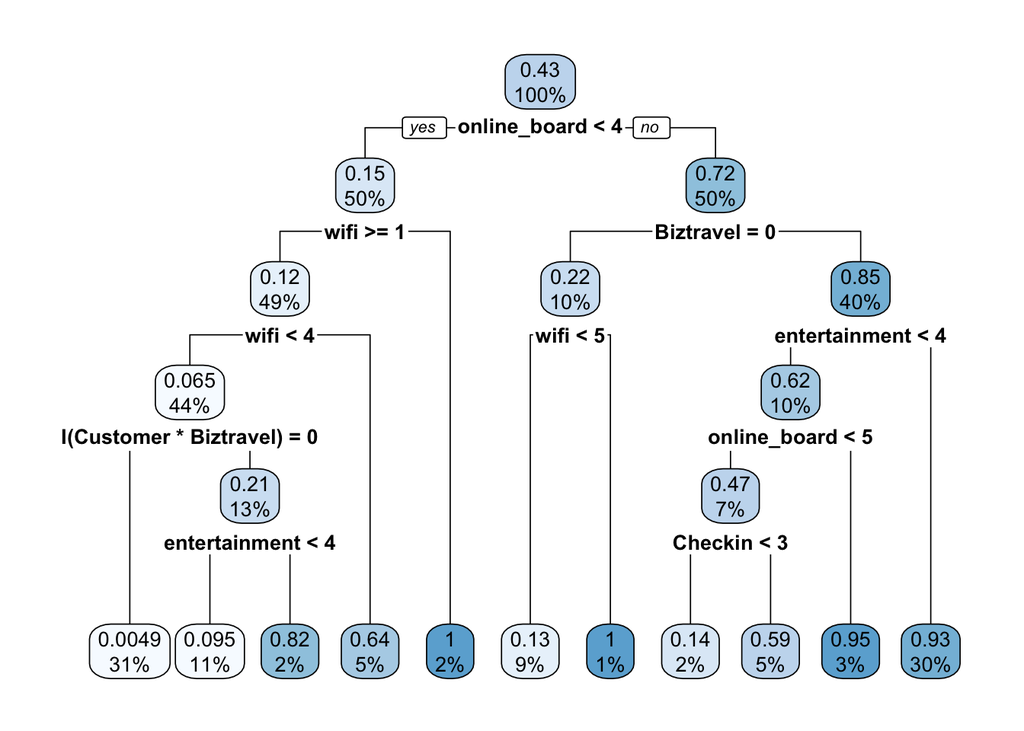

```r
rpart.plot(tree.model.clean)
```

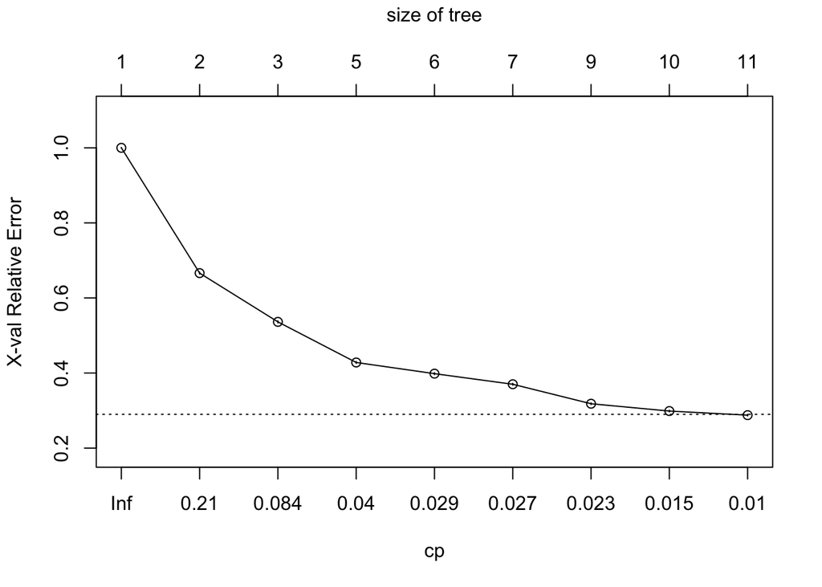

```r
plotcp(tree.model.clean)
```

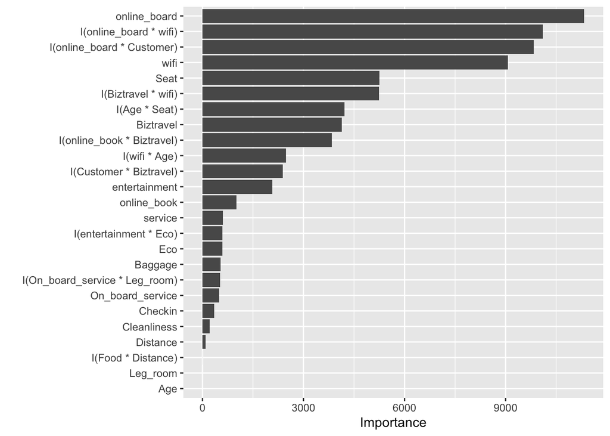

```r
vip(tree.model.clean,num_features = 40)
```